# Factors influencing the rental bid of hawker stalls

19 June 2021

# 1. Hawker stall rental analysis

## 1.1 Problem Statement

During last December 2020, Singapore’s Hawker Culture was acknowledged as part of UNESCO Representative List of the Intangible Cultural of Humanity. This acknowledgment aptly reinforced Singapore as being a multicultural city as it reflects our multicultural identity as a people and nation, that resonates strongly with all Singaporeans across all races and social strata.

Since then, there are more younger Singaporeans who are willing to embark into this hawker culture, bringing in affordable fusion and international food, while adding a bit of spice and novelty to the various local delicacies from the different races.

For a person interested to venture into this scene, there will be a need to decide what type of hawker trade to embark on and the location of hawker stall to rent out, before submitting the tender bid through the National Environment Agency (NEA). NEA will offer monthly tender notices to the public on available hawker stalls for rental and specifies the location and type of trade/products allowed. Interested applicants will need to undergo a bidding process. NEA will then award the hawker stall to the tenderer with the highest rental bid.

For our capstone project, we are interested to examine the factors that influence the rental bid of hawker stalls, specifically:

- How stall size affect the tendered rental bid and whether the accessibility to the hawker stall alters this relationship
- How stall type (cooked food, locked-up and market stall) affects the tendered rental bid and whether the location of the hawker stall alters this relationship. In this context, locked-up stall refers to stalls that provides services or dried goods. Market stall in general refers to stalls that sells fresh produce.

## 1.2 Import

The project will require the usage of data from the National Environmental Agency (NEA) on the list of successful tendered stalls per month, from March 2012 to March 2021. This will be supplemented with other data sources from readily available APIs and web scraping from websites.

- [List of Successsful Tendered Rental Bids from 2012 to 2021 in csv format](https://www.nea.gov.sg/docs/default-source/hawker-centres-documents/tender-notice-docs/successful-tenderers/tender-bids-from-mar-2012-to-mar-2021.pdf)
- [List of Government Markets Hawker Centres from NEA API](https://data.gov.sg/dataset/list-of-government-markets-hawker-centres)
- [Latitude and Longitude of hawker stalls from OneMap API](https://www.onemap.gov.sg/docs/#search)
- [Regions that hawker stall is located, i.e. Central or Non-Central. As a proxy, we will rely on the classification used for properties, by webscraping from propertyguru website](https://www.propertyguru.com.sg/property-guides/ccr-ocr-rcr-region-singapore-ura-map-21045)
- [List of MRT in Singapore from Dataworld in csv format](https://data.world/hxchua/train-stations-in-singapore)
- [List of Bus Stops in Singapore from the LTA Bus Stops API](https://datamall.lta.gov.sg/content/dam/datamall/datasets/LTA_DataMall_API_User_Guide.pdf)
- [List of Carparks in Singapore from the HDB website](https://data.gov.sg/dataset/hdb-carpark-information)

The data have been cleaned, merged and saved in `successful_bids_df.csv`.

To initiate our analysis, we activated the following packages, using the `Tidyverse` approach.

```r
pacman::p_load(tidyverse)
```

Then, we imported our dataset.

```r
successful_bids_df <- read_csv("successful_bids_df.csv")
```

## 1.3 Basic Visualization

To gain a better understanding of our data, we will create plots with basic visualization from the dataset. We plot the location of the hawker stalls with respect to the tendered rental bid.

```r
pacman::p_load(leaflet)
```

```r
successful_bids_df %>%
  leaflet() %>%
  addProviderTiles(providers$CartoDB.DarkMatter) %>%
  setView(
    lng = 103.8198,
    lat = 1.3521,
    zoom = 11
  ) %>%
  addCircles(~hc_lon,
             ~hc_lat,
             popup = successful_bids_df$tendered_bid_per_month,
             weight = 3,
             radius = 40,
             color = ~ ifelse(tendered_bid_per_month < 500, "white",
                              ifelse(tendered_bid_per_month < 1000, "yellow",
                                     ifelse(tendered_bid_per_month < 1500, "green",
                                            ifelse(tendered_bid_per_month < 2000, "orange",
                                                   ifelse(tendered_bid_per_month < 2500,"red","red"))))),
             stroke = TRUE,
             fillOpacity = 0.8) %>%
  addLegend("bottomright",
            colors = c("white","yellow","green","orange","red"),
            labels = c("Below $500","$500-$1000","$1000-$1500","$1500-$2000","Above $2500"),
            title = "Tendered Rental Bids")
```

[interactive chart not shown]

Here, it appears that hawker stalls are concentrated in the central, west, south and eastern regions of Singapore. On average, most of the hawker stalls have tendered rental bid of less than $1500, although there were a few with higher rental bids.

Next, we will take a look at the various trades of the stall type - cooked, locked-up and market stalls.

```r
boxplot_trade_cooked <- successful_bids_df %>%
  filter(stall_type == "cooked_food_stalls") %>%
  ggplot(aes(x=reorder(trade, tendered_bid_per_month), y=tendered_bid_per_month)) +
  geom_boxplot(aes(fill=trade)) +
  labs(title = "Cooked Food Stall",
       x = "Stall Size (in square metre)",
       y = "Tendered Rental Bid") +
  coord_cartesian(ylim = c(0,5000)) +
  ggthemes::theme_fivethirtyeight() +
  theme(plot.title = element_text(size=10),
        plot.subtitle = element_text(size=10),
        legend.position = "none",
        axis.text.x = element_text(angle = 45,
                                   size=8))

boxplot_trade_locked <- successful_bids_df %>%
  filter(stall_type == "locked_up_stalls") %>%
  ggplot(aes(x=reorder(trade, tendered_bid_per_month), y=tendered_bid_per_month)) +
  geom_boxplot(aes(fill=trade)) +
  labs(title = "Locked-Up Stall",
       x = "Stall Size (in square metre)",
       y = "Tendered Rental Bid") +
  coord_cartesian(ylim = c(0,5000)) +
  ggthemes::theme_fivethirtyeight() +
  theme(plot.title = element_text(size=10),
        plot.subtitle = element_text(size=10),
        legend.position = "none",
        axis.text.x = element_text(angle = 45,
                                   size=8))

boxplot_trade_market <- successful_bids_df %>%
  filter(stall_type == "market_stalls") %>%
  mutate(trade2 = case_when(trade == "VEGETABLES" ~ "VEGETABLES",
                            trade == "WHOLE FRUITS" ~ "WHOLE FRUITS",
                            trade == "FLOWERS" ~ "FLOWERS",
                            trade %in% c("HALAL FROZEN GOODS", "HALAL BEEF", "HALAL MUTTON", "HALAL POULTRY", "HALAL POUTLRY") ~ "HALAL MEAT",
                            trade %in%c("FROZEN GOODS", "BEEF", "MUTTON", "PORK", "POULTRY") ~ "MEAT",
                            trade %in% c("FRESH SEA FOOD", "FRESH SEAFOOD", "PROCESSED RAW SEAFOOD") ~ "SEAFOOD",
                            trade %in% c("ASSORTED SPICES", "BEANCAKES & NOODLES", "EGGS", "PRESERVED & DRIED GOODS", "PIECE & SUNDRY GOODS") ~ "DRIED GOODS AND SUNDRY")) %>%
  ggplot(aes(x=reorder(trade2, tendered_bid_per_month), y=tendered_bid_per_month)) +
  geom_boxplot(aes(fill=trade2)) +
  labs(title = "Market Stall",
       x = "Stall Size (in square metre)",
       y = "Tendered Rental Bid") +
  coord_cartesian(ylim = c(0,5000)) +
  ggthemes::theme_fivethirtyeight() +
  theme(plot.title = element_text(size=10),
        plot.subtitle = element_text(size=10),
        legend.position = "none",
        axis.text.x = element_text(angle = 45,
                                   size=8))
```

On the surface, it seems that cooked food stalls command a higher tendered rental bid than locked-up and market stalls. We will confirm this understanding in the subsequent analysis by creating and visualizing the models.

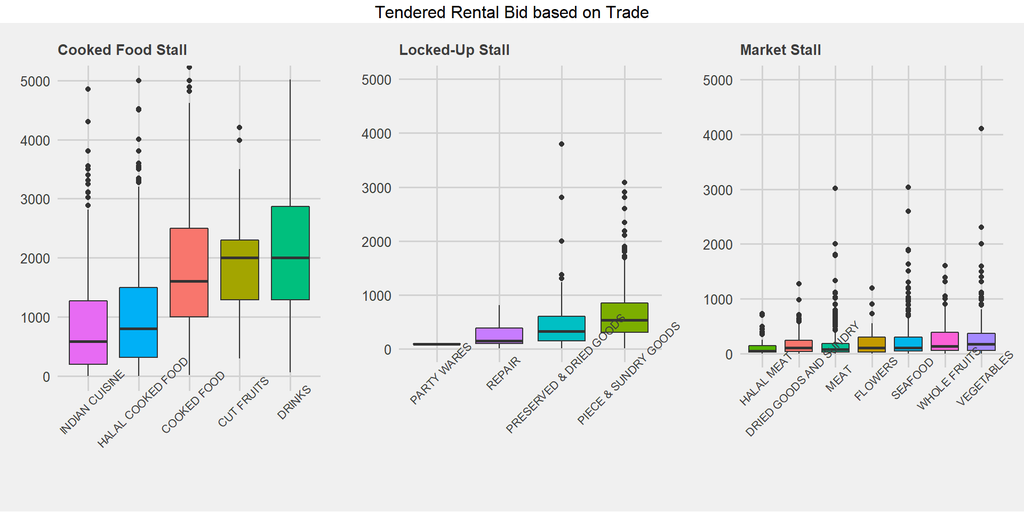

```r
gridExtra::grid.arrange(boxplot_trade_cooked,
                        boxplot_trade_locked,
                        boxplot_trade_market,
                        ncol=3,
                        top="Tendered Rental Bid based on Trade")
```

## 1.4 Tidy & Transform

For creation of the model, the variable `tendered_bid_per_month` will serve as our dependent Y variable. The independent X variables are `stall_area_sqm`,`stall_type`,`hc_region`,`hc_dist_to_mrt`,`hc_dist_to_bus` and `hc_dist_to_carpark`.

```r
successful_bids_df <- successful_bids_df %>%
  mutate(min_dist_public_trnspt = rowMeans(successful_bids_df %>%
                                             select(hc_dist_to_mrt,
                                                    hc_dist_to_bus)),
         min_dist_private_trnspt = hc_dist_to_carpark,
         cooked = case_when(stall_type %in% c("locked_up_stalls",
                                              "market_stalls") ~ 0,
                            stall_type == "cooked_food_stalls" ~ 1),
         central = case_when(hc_region %in% c("Rest of Central Region",
                                              "Outside Central Region") ~ 0,
                             hc_region == "Core Central Region" ~ 1),
         tendered_bid = round(tendered_bid_per_month))
```

## 1.5 Ordinary Least Squares Regression

For the preparation of the model, we created and ran a correlational matrix, to examine how our variables of interest within the model are related.

```r
pacman::p_load(Hmisc, broom)
```

```r
successful_bids_df %>%
  select(tendered_bid, stall_area_sqm, cooked, central,
         min_dist_public_trnspt, min_dist_private_trnspt) %>%
  as.matrix(.) %>%
  Hmisc::rcorr(.) %>%
  broom::tidy(.) %>%
  arrange(desc(estimate)) %>%
  print(n = nrow(.))
```

```
## # A tibble: 15 x 5
##    column1                 column2                estimate     n    p.value
##    <chr>                   <chr>                     <dbl> <int>      <dbl>
##  1 cooked                  tendered_bid             0.579   5676 0
##  2 min_dist_private_trnspt central                  0.474   5676 0
##  3 central                 tendered_bid             0.374   5676 0
##  4 min_dist_private_trnspt tendered_bid             0.308   5676 0
##  5 min_dist_private_trnspt cooked                   0.267   5676 0
##  6 central                 cooked                   0.240   5676 0
##  7 cooked                  stall_area_sqm           0.209   5676 0
##  8 stall_area_sqm          tendered_bid             0.143   5676 0
##  9 min_dist_private_trnspt min_dist_public_trnspt   0.0640  5676 0.00000142
## 10 min_dist_public_trnspt  stall_area_sqm           0.0223  5676 0.0930
## 11 min_dist_public_trnspt  tendered_bid            -0.0113  5676 0.393
## 12 central                 stall_area_sqm          -0.0234  5676 0.0783
## 13 min_dist_public_trnspt  cooked                  -0.0382  5676 0.00404
## 14 min_dist_private_trnspt stall_area_sqm          -0.0426  5676 0.00131
## 15 min_dist_public_trnspt  central                 -0.131   5676 0
```

## 1.5.1 Main Effects Only

We then ran two regression models. The first model with main effects regressed stall size, location and accessibility onto tendered rental bid (`ols_main`). As the continuous data are right skewed, we also attempted the models with main effects using log transformation (`ols_main_log`) and square root transformation (`ols_main_sqrt`).

$$\begin{eqnarray}
\widehat{tendered\_bid} = intercept + b_1stall\_area + b_2min\_dist\_public\_trnspt + \\b_3min\_dist\_private\_trnspt + b_4cooked + b_5central + \epsilon
\end{eqnarray}$$

```r
ols_main <- lm(tendered_bid ~ stall_area_sqm + min_dist_public_trnspt + min_dist_private_trnspt
               + cooked + central,
               data = successful_bids_df)

broom::glance(ols_main); broom::tidy(ols_main) %>% as_tibble()
```

```
## # A tibble: 1 x 12
##   r.squared adj.r.squared sigma statistic p.value    df  logLik    AIC    BIC
##       <dbl>         <dbl> <dbl>     <dbl>   <dbl> <dbl>   <dbl>  <dbl>  <dbl>
## 1     0.400         0.400  741.      757.       0     5 -45558. 91130. 91177.
## # ... with 3 more variables: deviance <dbl>, df.residual <int>, nobs <int>
```

```
## # A tibble: 6 x 5
##   term                    estimate std.error statistic  p.value
##   <chr>                      <dbl>     <dbl>     <dbl>    <dbl>
## 1 (Intercept)              100.      41.2         2.43 1.49e- 2
## 2 stall_area_sqm            23.5      5.42        4.34 1.46e- 5
## 3 min_dist_public_trnspt     0.147    0.0481      3.07 2.18e- 3
## 4 min_dist_private_trnspt    0.312    0.0559      5.58 2.48e- 8
## 5 cooked                   965.      21.5        44.9  0
## 6 central                  800.      42.0        19.0  2.08e-78
```

```r
ols_main_log <-
  lm(log(tendered_bid) ~ log(stall_area_sqm) +
       log(min_dist_public_trnspt) + log(min_dist_private_trnspt) +
       cooked + central,
     data = successful_bids_df)

broom::glance(ols_main_log); broom::tidy(ols_main_log) %>% as_tibble()
```

```
## # A tibble: 1 x 12
##   r.squared adj.r.squared sigma statistic p.value    df logLik    AIC    BIC
##       <dbl>         <dbl> <dbl>     <dbl>   <dbl> <dbl>  <dbl>  <dbl>  <dbl>
## 1     0.360         0.359  1.28      638.       0     5 -9453. 18921. 18967.
## # ... with 3 more variables: deviance <dbl>, df.residual <int>, nobs <int>
```

```
## # A tibble: 6 x 5
##   term                         estimate std.error statistic   p.value
##   <chr>                           <dbl>     <dbl>     <dbl>     <dbl>
## 1 (Intercept)                   2.78       0.219     12.7   1.86e- 36
## 2 log(stall_area_sqm)           1.15       0.0657    17.5   4.49e- 67
## 3 log(min_dist_public_trnspt)   0.0306     0.0341     0.897 3.70e-  1
## 4 log(min_dist_private_trnspt) -0.00596    0.0130    -0.460 6.46e-  1
## 5 cooked                        1.52       0.0369    41.0   3   e-322
## 6 central                       0.931      0.0706    13.2   4.27e- 39
```

```r
ols_main_sqrt <-
  lm(sqrt(tendered_bid) ~ sqrt(stall_area_sqm) +
       sqrt(min_dist_public_trnspt) + sqrt(min_dist_private_trnspt) +
       cooked + central,
     data = successful_bids_df)

broom::glance(ols_main_sqrt); broom::tidy(ols_main_sqrt) %>% as_tibble()
```

```
## # A tibble: 1 x 12
##   r.squared adj.r.squared sigma statistic p.value    df  logLik    AIC    BIC
##       <dbl>         <dbl> <dbl>     <dbl>   <dbl> <dbl>   <dbl>  <dbl>  <dbl>
## 1     0.439         0.438  11.6      887.       0     5 -21951. 43915. 43962.
## # ... with 3 more variables: deviance <dbl>, df.residual <int>, nobs <int>
```

```
## # A tibble: 6 x 5
##   term                          estimate std.error statistic  p.value
##   <chr>                            <dbl>     <dbl>     <dbl>    <dbl>
## 1 (Intercept)                     0.826     1.32       0.625 5.32e- 1
## 2 sqrt(stall_area_sqm)            5.09      0.462     11.0   5.55e-28
## 3 sqrt(min_dist_public_trnspt)    0.0356    0.0323     1.10  2.70e- 1
## 4 sqrt(min_dist_private_trnspt)   0.166     0.0304     5.48  4.52e- 8
## 5 cooked                         16.6       0.337     49.2   0
## 6 central                        10.8       0.680     15.9   1.12e-55
```

## 1.5.2 With Interaction

$$\begin{eqnarray}
\widehat{tendered\_bid} = intercept + b_1stall\_area + b_2min\_dist\_public\_trnspt + b_3min\_dist\_private\_trnspt + b_4cooked + \\b_5central + b_7stall\_area \times min\_dist\_public\_trnspt + b_8stall\_area \times in\_dist\_private\_trnspt + \epsilon
\end{eqnarray}$$

```r
ols_interact <-
  lm(tendered_bid ~
       stall_area_sqm * (min_dist_public_trnspt + min_dist_private_trnspt) +
       cooked + central,
     data = successful_bids_df)

broom::glance(ols_interact);broom::tidy(ols_interact) %>% as_tibble()
```

```
## # A tibble: 1 x 12
##   r.squared adj.r.squared sigma statistic p.value    df  logLik    AIC    BIC
##       <dbl>         <dbl> <dbl>     <dbl>   <dbl> <dbl>   <dbl>  <dbl>  <dbl>
## 1     0.403         0.402  740.      546.       0     7 -45547. 91112. 91172.
## # ... with 3 more variables: deviance <dbl>, df.residual <int>, nobs <int>
```

```
## # A tibble: 8 x 5
##   term                                   estimate std.error statistic  p.value
##   <chr>                                     <dbl>     <dbl>     <dbl>    <dbl>
## 1 (Intercept)                            133.       76.4         1.74 8.13e- 2
## 2 stall_area_sqm                          20.5      10.3         1.99 4.67e- 2
## 3 min_dist_public_trnspt                   0.349     0.208       1.68 9.40e- 2
## 4 min_dist_private_trnspt                 -0.782     0.240      -3.26 1.14e- 3
## 5 cooked                                 967.       21.5        45.1  0
## 6 central                                813.       42.1        19.3  1.69e-80
## 7 stall_area_sqm:min_dist_public_trnspt   -0.0351    0.0286     -1.23 2.19e- 1
## 8 stall_area_sqm:min_dist_private_trnspt   0.160     0.0342      4.69 2.77e- 6
```

```r
ols_interact_log <-
  lm(log(tendered_bid) ~
       log(stall_area_sqm) * (log(min_dist_public_trnspt) + log(min_dist_private_trnspt)) +
       cooked + central,
     data = successful_bids_df)

broom::glance(ols_interact_log);broom::tidy(ols_interact_log) %>% as_tibble()
```

```
## # A tibble: 1 x 12
##   r.squared adj.r.squared sigma statistic p.value    df logLik    AIC    BIC
##       <dbl>         <dbl> <dbl>     <dbl>   <dbl> <dbl>  <dbl>  <dbl>  <dbl>
## 1     0.364         0.363  1.28      464.       0     7 -9435. 18888. 18948.
## # ... with 3 more variables: deviance <dbl>, df.residual <int>, nobs <int>
```

```
## # A tibble: 8 x 5
##   term                                    estimate std.error statistic   p.value
##   <chr>                                      <dbl>     <dbl>     <dbl>     <dbl>
## 1 (Intercept)                               -0.682    1.34      -0.510 6.10e-  1
## 2 log(stall_area_sqm)                        3.01     0.693      4.34  1.42e-  5
## 3 log(min_dist_public_trnspt)                0.996    0.244      4.09  4.44e-  5
## 4 log(min_dist_private_trnspt)              -0.547    0.0981    -5.58  2.55e-  8
## 5 cooked                                     1.51     0.0368    41.1   2   e-323
## 6 central                                    0.945    0.0705    13.4   2.08e- 40
## 7 log(stall_area_sqm):log(min_dist_publi~   -0.512    0.127     -4.04  5.50e-  5
## 8 log(stall_area_sqm):log(min_dist_priva~    0.283    0.0507     5.59  2.34e-  8
```

```r
ols_interact_sqrt <-
  lm(sqrt(tendered_bid) ~
       sqrt(stall_area_sqm) * (sqrt(min_dist_public_trnspt) + sqrt(min_dist_private_trnspt)) +
       cooked + central,
     data = successful_bids_df)

broom::glance(ols_interact_sqrt);broom::tidy(ols_interact_sqrt) %>% as_tibble()
```

```
## # A tibble: 1 x 12
##   r.squared adj.r.squared sigma statistic p.value    df  logLik    AIC    BIC
##       <dbl>         <dbl> <dbl>     <dbl>   <dbl> <dbl>   <dbl>  <dbl>  <dbl>
## 1     0.442         0.441  11.5      641.       0     7 -21935. 43887. 43947.
## # ... with 3 more variables: deviance <dbl>, df.residual <int>, nobs <int>
```

```
## # A tibble: 8 x 5
##   term                                     estimate std.error statistic  p.value
##   <chr>                                       <dbl>     <dbl>     <dbl>    <dbl>
## 1 (Intercept)                                 2.40     4.64       0.517 6.05e- 1
## 2 sqrt(stall_area_sqm)                        4.69     1.73       2.71  6.65e- 3
## 3 sqrt(min_dist_public_trnspt)                0.537    0.252      2.13  3.32e- 2
## 4 sqrt(min_dist_private_trnspt)              -1.15     0.237     -4.83  1.37e- 6
## 5 cooked                                     16.6      0.336     49.5   0
## 6 central                                    11.1      0.681     16.3   4.10e-58
## 7 sqrt(stall_area_sqm):sqrt(min_dist_publ~   -0.202    0.0954    -2.12  3.41e- 2
## 8 sqrt(stall_area_sqm):sqrt(min_dist_priv~    0.501    0.0894     5.60  2.24e- 8
```

## 1.5.3 Model Comparison

**Adjusted R-squared**

For the models with main effects `ols_main`,`ols_main_log`,`ols_main_sqrt`, the adjusted R-squared are `0.400`, `0.359` and `0.438` respectively.

For the models with interaction `ols_interact`,`ols_interact_log`,`ols_interact_sqrt`, the adjusted R-squared are `0.402`, `0.363` and `0.441` respectively.

Compared to the models with main effects, the adjusted R-squared of the corresponding models with interaction terms are higher. This suggests that adding the interaction terms improves the explanatory power of the model.

**ANOVA**

We also compared the models using ANOVA.

```r
anova(ols_main, ols_interact)
```

```
## Analysis of Variance Table
##
## Model 1: tendered_bid ~ stall_area_sqm + min_dist_public_trnspt + min_dist_private_trnspt +
##     cooked + central
## Model 2: tendered_bid ~ stall_area_sqm * (min_dist_public_trnspt + min_dist_private_trnspt) +
##     cooked + central
##   Res.Df        RSS Df Sum of Sq      F    Pr(>F)
## 1   5670 3113397877
## 2   5668 3101347622  2  12050254 11.011 1.687e-05 ***
## ---
## Signif. codes:  0 '***' 0.001 '**' 0.01 '*' 0.05 '.' 0.1 ' ' 1
```

```r
anova(ols_main_log, ols_interact_log)
```

```
## Analysis of Variance Table
##
## Model 1: log(tendered_bid) ~ log(stall_area_sqm) + log(min_dist_public_trnspt) +
##     log(min_dist_private_trnspt) + cooked + central
## Model 2: log(tendered_bid) ~ log(stall_area_sqm) * (log(min_dist_public_trnspt) +
##     log(min_dist_private_trnspt)) + cooked + central
##   Res.Df    RSS Df Sum of Sq      F    Pr(>F)
## 1   5670 9294.3
## 2   5668 9234.0  2    60.249 18.491 9.898e-09 ***
## ---
## Signif. codes:  0 '***' 0.001 '**' 0.01 '*' 0.05 '.' 0.1 ' ' 1
```

```r
anova(ols_main_sqrt, ols_interact_sqrt)
```

```
## Analysis of Variance Table
##
## Model 1: sqrt(tendered_bid) ~ sqrt(stall_area_sqm) + sqrt(min_dist_public_trnspt) +
##     sqrt(min_dist_private_trnspt) + cooked + central
## Model 2: sqrt(tendered_bid) ~ sqrt(stall_area_sqm) * (sqrt(min_dist_public_trnspt) +
##     sqrt(min_dist_private_trnspt)) + cooked + central
##   Res.Df    RSS Df Sum of Sq      F    Pr(>F)
## 1   5670 759672
## 2   5668 755402  2    4269.8 16.019 1.155e-07 ***
## ---
## Signif. codes:  0 '***' 0.001 '**' 0.01 '*' 0.05 '.' 0.1 ' ' 1
```

From the results, the models with interaction terms has Df of 2, indicating that the more complex model (with interaction terms) has two additional parameters, and a very small p-value (less than 0.05). This implies that adding interaction terms did significantly improve fit of the model.

## 1.5.4 Multicollinearity Check

We will then check for Multicollinearity using the `vif` function under the `car` library.

```r
pacman::p_load(car)
```

```r
vif(ols_main)
```

```
##          stall_area_sqm  min_dist_public_trnspt min_dist_private_trnspt
##                1.059979                1.041421                1.371635
##                  cooked                 central
##                1.160734                1.356459
```

```r
vif(ols_main_log)
```

```
##          log(stall_area_sqm)  log(min_dist_public_trnspt)
##                     1.095850                     1.141830
## log(min_dist_private_trnspt)                       cooked
##                     1.316512                     1.149650
##                      central
##                     1.284038
```

```r
vif(ols_main_sqrt)
```

```
##          sqrt(stall_area_sqm)  sqrt(min_dist_public_trnspt)
##                      1.084300                      1.075415
## sqrt(min_dist_private_trnspt)                        cooked
##                      1.487290                      1.171133
##                       central
##                      1.455544
```

```r
vif(ols_interact)
```

```
##                         stall_area_sqm                 min_dist_public_trnspt
##                               3.850667                              19.644593
##                min_dist_private_trnspt                                 cooked
##                              25.403725                               1.162860
##                                central  stall_area_sqm:min_dist_public_trnspt
##                               1.365802                              23.577150
## stall_area_sqm:min_dist_private_trnspt
##                              25.385720
```

```r
vif(ols_interact_log)
```

```
##                              log(stall_area_sqm)
##                                       122.722543
##                      log(min_dist_public_trnspt)
##                                        58.694790
##                     log(min_dist_private_trnspt)
##                                        75.751235
##                                           cooked
##                                         1.150566
##                                          central
##                                         1.285692
##  log(stall_area_sqm):log(min_dist_public_trnspt)
##                                       193.480247
## log(stall_area_sqm):log(min_dist_private_trnspt)
##                                        79.420436
```

```r
vif(ols_interact_sqrt)
```

```
##                               sqrt(stall_area_sqm)
##                                          15.275354
##                       sqrt(min_dist_public_trnspt)
##                                          65.989948
##                      sqrt(min_dist_private_trnspt)
##                                          90.963230
##                                             cooked
##                                           1.172834
##                                            central
##                                           1.468251
##  sqrt(stall_area_sqm):sqrt(min_dist_public_trnspt)
##                                          82.320620
## sqrt(stall_area_sqm):sqrt(min_dist_private_trnspt)
##                                          90.649190
```

In general, VIF of more than 4 will be an issue as it undermines the statistical significance of an independent variable.

From the results, the VIF of models with main effects are less than 4, hence there are no concerns.

As for the models with interaction effects, VIF of more than 4 are produced. However, this could be because interaction terms are created from the independent variables. Therefore, we will not be removing any of the variables from the model in our subsequent steps.

## 1.5.5 Assumption Check

To check for linearity, we shall utilize the Global Validation of Linear Model Assumption (GVLMA) package.

```r
pacman::p_load(gvlma, ggfortify)
```

```r
gvlma(ols_main)
```

```
##
## Call:
## lm(formula = tendered_bid ~ stall_area_sqm + min_dist_public_trnspt +
##     min_dist_private_trnspt + cooked + central, data = successful_bids_df)
##
## Coefficients:
##             (Intercept)           stall_area_sqm   min_dist_public_trnspt
##                100.2863                  23.5322                   0.1474
## min_dist_private_trnspt                   cooked                  central
##                  0.3120                 964.8508                 800.0686
##
##
## ASSESSMENT OF THE LINEAR MODEL ASSUMPTIONS
## USING THE GLOBAL TEST ON 4 DEGREES-OF-FREEDOM:
## Level of Significance =  0.05
##
## Call:
##  gvlma(x = ols_main)
##
##                       Value   p-value                   Decision
## Global Stat        30437.10 0.000e+00 Assumptions NOT satisfied!
## Skewness            2856.23 0.000e+00 Assumptions NOT satisfied!
## Kurtosis           26062.24 0.000e+00 Assumptions NOT satisfied!
## Link Function         40.48 1.987e-10 Assumptions NOT satisfied!
## Heteroscedasticity  1478.15 0.000e+00 Assumptions NOT satisfied!
```

```r
gvlma(ols_main_log)
```

```
##
## Call:
## lm(formula = log(tendered_bid) ~ log(stall_area_sqm) + log(min_dist_public_trnspt) +
##     log(min_dist_private_trnspt) + cooked + central, data = successful_bids_df)
##
## Coefficients:
##                  (Intercept)           log(stall_area_sqm)
##                     2.783575                      1.152467
##  log(min_dist_public_trnspt)  log(min_dist_private_trnspt)
##                     0.030583                     -0.005962
##                       cooked                       central
##                     1.515042                      0.930962
##
##
## ASSESSMENT OF THE LINEAR MODEL ASSUMPTIONS
## USING THE GLOBAL TEST ON 4 DEGREES-OF-FREEDOM:
## Level of Significance =  0.05
##
## Call:
##  gvlma(x = ols_main_log)
##
##                     Value p-value                   Decision
## Global Stat        1726.7       0 Assumptions NOT satisfied!
## Skewness            909.7       0 Assumptions NOT satisfied!
## Kurtosis            541.1       0 Assumptions NOT satisfied!
## Link Function       103.6       0 Assumptions NOT satisfied!
## Heteroscedasticity  172.4       0 Assumptions NOT satisfied!
```

```r
gvlma(ols_main_sqrt)
```

```
##
## Call:
## lm(formula = sqrt(tendered_bid) ~ sqrt(stall_area_sqm) + sqrt(min_dist_public_trnspt) +
##     sqrt(min_dist_private_trnspt) + cooked + central, data = successful_bids_df)
##
## Coefficients:
##                   (Intercept)           sqrt(stall_area_sqm)
##                       0.82560                        5.08873
##  sqrt(min_dist_public_trnspt)  sqrt(min_dist_private_trnspt)
##                       0.03558                        0.16634
##                        cooked                        central
##                      16.58801                       10.80516
##
##
## ASSESSMENT OF THE LINEAR MODEL ASSUMPTIONS
## USING THE GLOBAL TEST ON 4 DEGREES-OF-FREEDOM:
## Level of Significance =  0.05
##
## Call:
##  gvlma(x = ols_main_sqrt)
##
##                      Value p-value                   Decision
## Global Stat        606.631  0.0000 Assumptions NOT satisfied!
## Skewness            77.297  0.0000 Assumptions NOT satisfied!
## Kurtosis            87.123  0.0000 Assumptions NOT satisfied!
## Link Function        0.892  0.3449    Assumptions acceptable.
## Heteroscedasticity 441.319  0.0000 Assumptions NOT satisfied!
```

```r
gvlma(ols_interact)
```

```
##
## Call:
## lm(formula = tendered_bid ~ stall_area_sqm * (min_dist_public_trnspt +
##     min_dist_private_trnspt) + cooked + central, data = successful_bids_df)
##
## Coefficients:
##                            (Intercept)                          stall_area_sqm
##                              133.17521                                20.52848
##                 min_dist_public_trnspt                 min_dist_private_trnspt
##                                0.34903                                -0.78164
##                                 cooked                                 central
##                              967.01165                               812.62974
##  stall_area_sqm:min_dist_public_trnspt  stall_area_sqm:min_dist_private_trnspt
##                               -0.03509                                 0.16043
##
##
## ASSESSMENT OF THE LINEAR MODEL ASSUMPTIONS
## USING THE GLOBAL TEST ON 4 DEGREES-OF-FREEDOM:
## Level of Significance =  0.05
##
## Call:
##  gvlma(x = ols_interact)
##
##                       Value   p-value                   Decision
## Global Stat        30819.87 0.000e+00 Assumptions NOT satisfied!
## Skewness            2869.77 0.000e+00 Assumptions NOT satisfied!
## Kurtosis           26427.75 0.000e+00 Assumptions NOT satisfied!
## Link Function         35.58 2.452e-09 Assumptions NOT satisfied!
## Heteroscedasticity  1486.77 0.000e+00 Assumptions NOT satisfied!
```

```r
gvlma(ols_interact_log)
```

```
##
## Call:
## lm(formula = log(tendered_bid) ~ log(stall_area_sqm) * (log(min_dist_public_trnspt) +
##     log(min_dist_private_trnspt)) + cooked + central, data = successful_bids_df)
##
## Coefficients:
##                                      (Intercept)
##                                          -0.6822
##                              log(stall_area_sqm)
##                                           3.0124
##                      log(min_dist_public_trnspt)
##                                           0.9959
##                     log(min_dist_private_trnspt)
##                                          -0.5472
##                                           cooked
##                                           1.5141
##                                          central
##                                           0.9451
##  log(stall_area_sqm):log(min_dist_public_trnspt)
##                                          -0.5123
## log(stall_area_sqm):log(min_dist_private_trnspt)
##                                           0.2834
##
##
## ASSESSMENT OF THE LINEAR MODEL ASSUMPTIONS
## USING THE GLOBAL TEST ON 4 DEGREES-OF-FREEDOM:
## Level of Significance =  0.05
##
## Call:
##  gvlma(x = ols_interact_log)
##
##                     Value p-value                   Decision
## Global Stat        1731.0       0 Assumptions NOT satisfied!
## Skewness            911.9       0 Assumptions NOT satisfied!
## Kurtosis            538.6       0 Assumptions NOT satisfied!
## Link Function       120.2       0 Assumptions NOT satisfied!
## Heteroscedasticity  160.4       0 Assumptions NOT satisfied!
```

```r
gvlma(ols_interact_sqrt)
```

```
##
## Call:
## lm(formula = sqrt(tendered_bid) ~ sqrt(stall_area_sqm) * (sqrt(min_dist_public_trnspt) +
##     sqrt(min_dist_private_trnspt)) + cooked + central, data = successful_bids_df)
##
## Coefficients:
##                                        (Intercept)
##                                             2.3961
##                               sqrt(stall_area_sqm)
##                                             4.6908
##                       sqrt(min_dist_public_trnspt)
##                                             0.5370
##                      sqrt(min_dist_private_trnspt)
##                                            -1.1453
##                                             cooked
##                                            16.6465
##                                            central
##                                            11.0713
##  sqrt(stall_area_sqm):sqrt(min_dist_public_trnspt)
##                                            -0.2021
## sqrt(stall_area_sqm):sqrt(min_dist_private_trnspt)
##                                             0.5009
##
##
## ASSESSMENT OF THE LINEAR MODEL ASSUMPTIONS
## USING THE GLOBAL TEST ON 4 DEGREES-OF-FREEDOM:
## Level of Significance =  0.05
##
## Call:
##  gvlma(x = ols_interact_sqrt)
##
##                      Value p-value                   Decision
## Global Stat        621.761 0.00000 Assumptions NOT satisfied!
## Skewness            81.149 0.00000 Assumptions NOT satisfied!
## Kurtosis            85.953 0.00000 Assumptions NOT satisfied!
## Link Function        4.386 0.03623 Assumptions NOT satisfied!
## Heteroscedasticity 450.273 0.00000 Assumptions NOT satisfied!
```

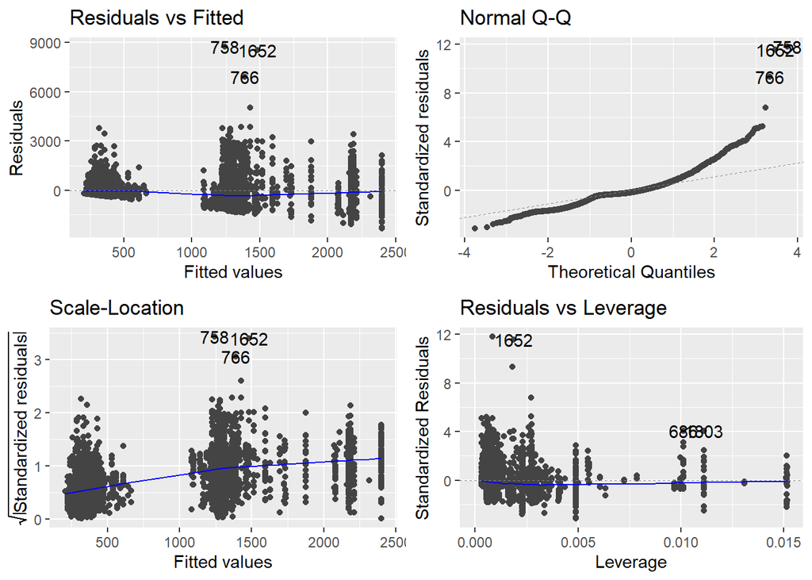

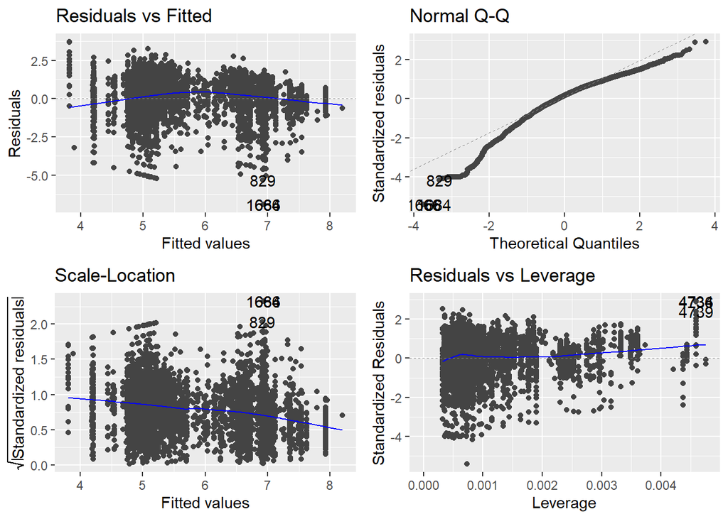

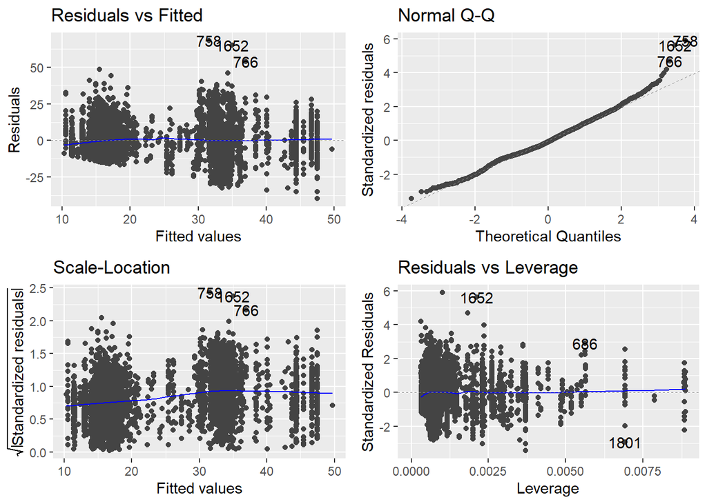

```r
autoplot(gvlma(ols_main))
autoplot(gvlma(ols_main_log))
autoplot(gvlma(ols_main_sqrt))
```

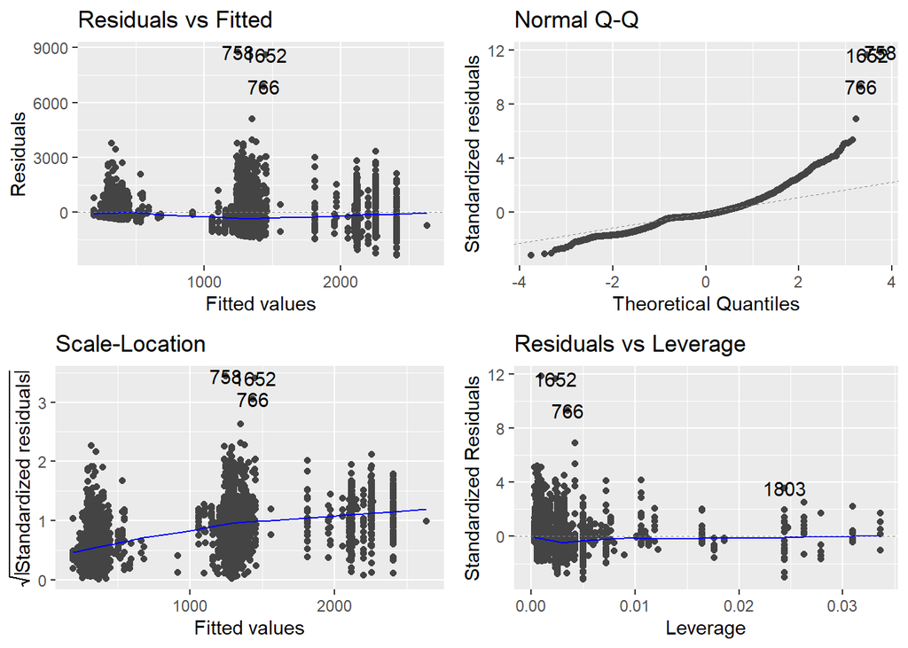

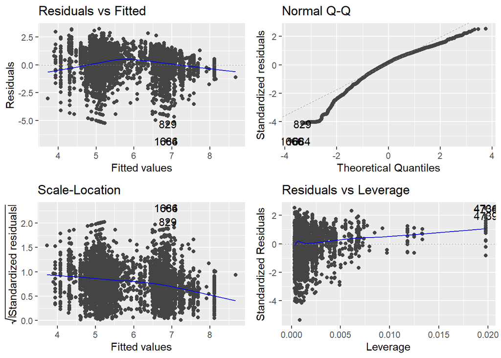

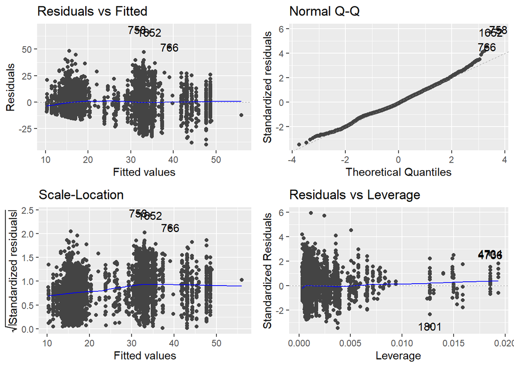

```r
autoplot(gvlma(ols_interact))
autoplot(gvlma(ols_interact_log))
autoplot(gvlma(ols_interact_sqrt))
```

Unfortunately, the results show that the assumptions of linearity are not satisfied for the OLS models that we have created to investigate if the stall size affects the tendered rental bid. Hence, we will not move on with our second investigation on whether stall type (`cooked`) affects the tendered rental bid using OLS.

Instead, we turned to Poisson regression model as it can account for non-linear relationships between the Y and X variables.

## 1.6 Poisson Regression Model

## 1.6.1 Main Effects

We ran two Poisson Regression models. The first model with main effects regressed stall size, location and accessibility onto tendered rental bid (`poisson_main`).

```r
poisson_main <-
glm(tendered_bid ~ stall_area_sqm + min_dist_public_trnspt +
      min_dist_private_trnspt + cooked + central,
    family="poisson",
    data = successful_bids_df)

broom::glance(poisson_main);broom::tidy(poisson_main) %>% as_tibble()
```

```
## # A tibble: 1 x 8
##   null.deviance df.null    logLik      AIC      BIC deviance df.residual  nobs
##           <dbl>   <int>     <dbl>    <dbl>    <dbl>    <dbl>       <int> <int>
## 1      5315300.    5675 -1485182. 2970377. 2970417. 2926779.        5670  5676
```

```
## # A tibble: 6 x 5
##   term                    estimate  std.error statistic p.value
##   <chr>                      <dbl>      <dbl>     <dbl>   <dbl>
## 1 (Intercept)             5.51     0.00219       2517.        0
## 2 stall_area_sqm          0.0350   0.000277       126.        0
## 3 min_dist_public_trnspt  0.000212 0.00000219      96.7       0
## 4 min_dist_private_trnspt 0.000142 0.00000186      76.5       0
## 5 cooked                  1.31     0.00114       1146.        0
## 6 central                 0.578    0.00143        405.        0
```

Our key investigation lies in the subsequent models, where we regressed

- stall size along with accessibility as interaction term, onto tendered rental bid (`poisson_interact_A`)
- stall type along with location as interaction term, onto tendered rental bid (`poisson_interact_B`)

## 1.6.2 Stall Size X Accessibility

We regress stall size along with accessibility as interaction terms, onto tendered rental bid.

```r
poisson_interact_A <- glm(tendered_bid ~ stall_area_sqm * (min_dist_public_trnspt + min_dist_private_trnspt) +
        cooked + central,
      family="poisson",
      data = successful_bids_df)

broom::glance(poisson_interact_A);broom::tidy(poisson_interact_A) %>% as_tibble()
```

```
## # A tibble: 1 x 8
##   null.deviance df.null    logLik      AIC      BIC deviance df.residual  nobs
##           <dbl>   <int>     <dbl>    <dbl>    <dbl>    <dbl>       <int> <int>
## 1      5315300.    5675 -1483484. 2966984. 2967037. 2923382.        5668  5676
```

```
## # A tibble: 8 x 5
##   term                                     estimate std.error statistic   p.value
##   <chr>                                       <dbl>     <dbl>     <dbl>     <dbl>
## 1 (Intercept)                             5.52        4.14e-3    1333.  0
## 2 stall_area_sqm                          0.0343      5.42e-4      63.2 0
## 3 min_dist_public_trnspt                  0.000392    1.15e-5      34.0 5.57e-253
## 4 min_dist_private_trnspt                -0.000365    9.02e-6     -40.5 0
## 5 cooked                                  1.31        1.15e-3    1145.  0
## 6 central                                 0.583       1.45e-3     403.  0
## 7 stall_area_sqm:min_dist_public_trnspt  -0.0000296   1.56e-6     -19.0 1.00e- 80
## 8 stall_area_sqm:min_dist_private_trnspt  0.0000732   1.26e-6      58.0 0
```

To visualize whether accessibility affects the relationship between the tendered rental bid and stall size, we categorized the distance from hawker stall to public transport into 3 levels - very accessible (M - 1SD), accessible (M) and not accessible (M + 1SD). Except for the stall size which is the explanatory variable, the rest of the variables are controlled by setting the values at their mean.

We stored the predicted values for the interaction terms `min_dist_public_trnspt` and `min_dist_public_trnspt`, in two grids respectively, to prepare for two different visualizations of the model.

```r
pacman::p_load(modelr)
```

```r
stall_size_X_public_trnspt_grid <- successful_bids_df %>%
  data_grid(stall_area_sqm, # Explanatory variable
            cooked = mean(cooked),
            central = mean(central),
            min_dist_public_trnspt = c(mean(min_dist_public_trnspt) - sd(min_dist_public_trnspt),
                                       mean(min_dist_public_trnspt),
                                       mean(min_dist_public_trnspt + sd(min_dist_public_trnspt))),
            min_dist_private_trnspt = mean(min_dist_private_trnspt)
  ) %>%
  mutate(predicted_tendered_bid = predict(poisson_interact_A, . , type = "response"))
```

```r
stall_size_X_public_trnspt_grid
```

```
## # A tibble: 783 x 6
##    stall_area_sqm cooked central min_dist_public_trnspt min_dist_private_trnspt
##             <dbl>  <dbl>   <dbl>                  <dbl>                   <dbl>
##  1           2.08  0.418  0.0809                   112.                    114.
##  2           2.08  0.418  0.0809                   320.                    114.
##  3           2.08  0.418  0.0809                   529.                    114.
##  4           2.3   0.418  0.0809                   112.                    114.
##  5           2.3   0.418  0.0809                   320.                    114.
##  6           2.3   0.418  0.0809                   529.                    114.
##  7           3     0.418  0.0809                   112.                    114.
##  8           3     0.418  0.0809                   320.                    114.
##  9           3     0.418  0.0809                   529.                    114.
## 10           3.8   0.418  0.0809                   112.                    114.
## # ... with 773 more rows, and 1 more variable: predicted_tendered_bid <dbl>
```

```r
stall_size_X_private_trnspt_grid <- successful_bids_df %>%
  modelr::data_grid(stall_area_sqm, # Explanatory variable
                    cooked = mean(cooked),
                    central = mean(central),
                    min_dist_public_trnspt = mean(min_dist_public_trnspt),
                    min_dist_private_trnspt = c(mean(min_dist_private_trnspt)- sd(min_dist_private_trnspt),
                                                      mean(min_dist_private_trnspt),
                                                      mean(min_dist_private_trnspt) + sd(min_dist_private_trnspt))
  ) %>%
  mutate(predicted_tendered_bid = predict(poisson_interact_A, . , type = "response"))
```

```r
stall_size_X_private_trnspt_grid
```

```
## # A tibble: 783 x 6
##    stall_area_sqm cooked central min_dist_public_trnspt min_dist_private_trnspt
##             <dbl>  <dbl>   <dbl>                  <dbl>                   <dbl>
##  1           2.08  0.418  0.0809                   320.                   -92.2
##  2           2.08  0.418  0.0809                   320.                   114.
##  3           2.08  0.418  0.0809                   320.                   320.
##  4           2.3   0.418  0.0809                   320.                   -92.2
##  5           2.3   0.418  0.0809                   320.                   114.
##  6           2.3   0.418  0.0809                   320.                   320.
##  7           3     0.418  0.0809                   320.                   -92.2
##  8           3     0.418  0.0809                   320.                   114.
##  9           3     0.418  0.0809                   320.                   320.
## 10           3.8   0.418  0.0809                   320.                   -92.2
## # ... with 773 more rows, and 1 more variable: predicted_tendered_bid <dbl>
```

We then created visualization of the models to get a better understanding of the correlation between `stall_area_sqm` and `tendered_bid_per_month`, with accessibility as the interaction effects.

```r
stall_size_X_public_trnspt_visualize <-
stall_size_X_public_trnspt_grid  %>%
  ggplot(aes(x = stall_area_sqm, # Explanatory variable
             y = predicted_tendered_bid, # Y-hat
             color = factor(min_dist_public_trnspt) # Moderator
  )
  ) +
  scale_color_discrete(label=c("Very accessible","Mean","Not accessible")) +
  geom_line(size = 2) +
  labs(x="Stall Size (in square metres)",
       y="Tendered Bid for Rental of Hawker Stall",
       color="Accessibility to public transport") +
  theme_bw() +
  theme(plot.title = element_text(size=12, lineheight = 0.6),
        plot.subtitle = element_text(size=11, lineheight = 0.6),
        legend.position = c(0.15,0.8),
        legend.justification = "left",
        legend.title=element_text(size=7.5),
        legend.text=element_text(size=7.5))
```

```r
stall_size_X_private_trnspt_visualize <-
stall_size_X_private_trnspt_grid  %>%
  ggplot(aes(x = stall_area_sqm, # Explanatory variable
             y = predicted_tendered_bid, # Y-hat
             color = factor(min_dist_private_trnspt) # Moderator
  )
  ) +
  scale_color_discrete(label=c("Very accessible","Mean","Not accessible")) +
  geom_line(size = 2) +
  labs(x="Stall Size (in square metres)",
       y="Tendered Bid for Rental of Hawker Stall",
       color="Accessibility to private transport") +
  theme_bw() +
  theme(plot.title = element_text(size=12, lineheight = 0.6),
        plot.subtitle = element_text(size=11, lineheight = 0.6),
        legend.position = c(0.15,0.8),
        legend.justification = "left",
        legend.title=element_text(size=7.5),
        legend.text=element_text(size=7.5))
```

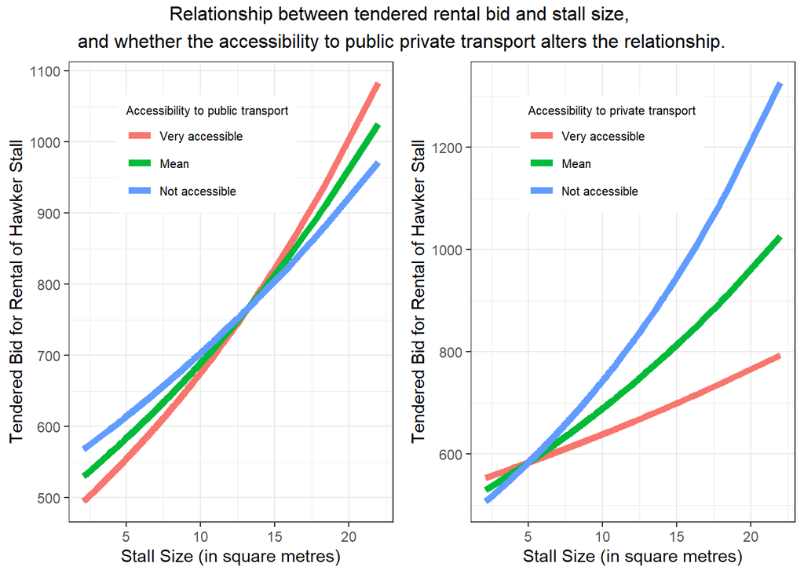

```r
gridExtra::grid.arrange(stall_size_X_public_trnspt_visualize,
                        stall_size_X_private_trnspt_visualize,
                        ncol=2,
                        top="Relationship between tendered rental bid and stall size, \nand whether the accessibility to public private transport alters the relationship.")
```

As the interaction terms are significant, we will proceed to probe interactions, with accessibility to public transport as the interaction term.

```r
pacman::p_load(interactions)
```

```r
interactions::sim_slopes(poisson_interact_A,
                         pred = stall_area_sqm,
                         modx = min_dist_public_trnspt,
                         johnson_neyman = F)
```

```
## SIMPLE SLOPES ANALYSIS
##
## Slope of stall_area_sqm when min_dist_public_trnspt = 111.54 (- 1 SD):
##
##   Est.   S.E.   z val.      p
## ------ ------ -------- ------
##   0.04   0.00    94.15   0.00
##
## Slope of stall_area_sqm when min_dist_public_trnspt = 320.40 (Mean):
##
##   Est.   S.E.   z val.      p
## ------ ------ -------- ------
##   0.03   0.00   118.69   0.00
##
## Slope of stall_area_sqm when min_dist_public_trnspt = 529.27 (+ 1 SD):
##
##   Est.   S.E.   z val.      p
## ------ ------ -------- ------
##   0.03   0.00    61.31   0.00
```

The results of the simple slopes analysis show that p = 0 in the three scenarios where hawker stalls are very accessible (M - 1SD), accessible (M) and not accessible (M + 1SD) by public transport. Given that p-value is less than 0.05, we can deduce that interaction effects are significant in the three levels of accessibility.

```r
interactions::sim_slopes(poisson_interact_A,
                         pred = min_dist_public_trnspt,
                         modx = stall_area_sqm,
                         johnson_neyman = T)
```

```
## JOHNSON-NEYMAN INTERVAL
##
## When stall_area_sqm is OUTSIDE the interval [12.65, 13.93], the slope of
## min_dist_public_trnspt is p < .05.
##
## Note: The range of observed values of stall_area_sqm is [2.08, 22.00]
##
## SIMPLE SLOPES ANALYSIS
##
## Slope of min_dist_public_trnspt when stall_area_sqm = 5.10 (- 1 SD):
##
##   Est.   S.E.   z val.      p
## ------ ------ -------- ------
##   0.00   0.00    59.08   0.00
##
## Slope of min_dist_public_trnspt when stall_area_sqm = 6.97 (Mean):
##
##   Est.   S.E.   z val.      p
## ------ ------ -------- ------
##   0.00   0.00    78.85   0.00
##
## Slope of min_dist_public_trnspt when stall_area_sqm = 8.84 (+ 1 SD):
##
##   Est.   S.E.   z val.      p
## ------ ------ -------- ------
##   0.00   0.00    38.62   0.00
```

The Johnson-Neyman interval shows that the slope for the accessibility via public transport is significant when the `stall_area_sqm` is outside the interval [12.65, 13.93]. The p-value is 0 (significant) when the stall_area_sqm is at 5.10 (Mean - 1SD), 6.97 (Mean) and 8.84 (Mean + 1SD).

We created the visualization plot of the interaction effects with regions of significance.

```r
poisson_interact_public_trnspt_A <-
interactions:: interact_plot(poisson_interact_A,
                               pred = "stall_area_sqm",
                               modx = "min_dist_public_trnspt",
                               modx.labels = c("Very accessible (M-1SD)",
                                               "Accessible (M)",
                                               "Not accessible (M+1SD)"),
                               x.label = "Stall Size (in square metres)",
                               y.label ="Tendered Bid for Rental of Hawker Stall",
                               interval = T,
                               int.width = 0.95,
                               vary.lty = T,
                               line.thickness = 1,
                               legend.main = "Accessibility to public transport (MRT or bus)"
  ) +
  annotate("rect",
           fill = "yellow",
           alpha = 0.2,
           xmin = 0,
           xmax = 12.65,
           ymin = 0,
           ymax = 4000) +
    annotate("rect",
           fill = "grey",
           alpha = 0.2,
           xmin = 12.65,
           xmax = 25,
           ymin = 0,
           ymax = 4000) +
  ggthemes::theme_fivethirtyeight() +
  theme(plot.title = element_text(size=14),
        plot.subtitle = element_text(size=11),
        legend.position = "top",
        legend.direction = "vertical",
        legend.justification = "left",
        legend.title=element_text(size=7.5),
        legend.text=element_text(size=7.5)
  )
```

Next, we will do the same probing with accessibility to private transport as interaction term.

```r
interactions::sim_slopes(poisson_interact_A,
                         pred = stall_area_sqm,
                         modx = min_dist_private_trnspt,
                         johnson_neyman = F)
```

```
## SIMPLE SLOPES ANALYSIS
##
## Slope of stall_area_sqm when min_dist_private_trnspt = -92.23 (- 1 SD):
##
##   Est.   S.E.   z val.      p
## ------ ------ -------- ------
##   0.02   0.00    44.63   0.00
##
## Slope of stall_area_sqm when min_dist_private_trnspt = 113.93 (Mean):
##
##   Est.   S.E.   z val.      p
## ------ ------ -------- ------
##   0.03   0.00   118.69   0.00
##
## Slope of stall_area_sqm when min_dist_private_trnspt = 320.09 (+ 1 SD):
##
##   Est.   S.E.   z val.      p
## ------ ------ -------- ------
##   0.05   0.00   134.83   0.00
```

The results of the simple slopes analysis show that p = 0 in the three scenarios where hawker stalls are very accessible (M - 1SD), accessible (M) and not very accessible (M + 1SD) by private transport. Given that p-value is less than 0.05, we can deduce that interaction effects are significant in the 3 levels of accessibility.

```r
interactions::sim_slopes(poisson_interact_A,
                         pred = min_dist_private_trnspt,
                         modx = stall_area_sqm,
                         johnson_neyman = T)
```

```
## JOHNSON-NEYMAN INTERVAL
##
## When stall_area_sqm is OUTSIDE the interval [4.90, 5.07], the slope of
## min_dist_private_trnspt is p < .05.
##
## Note: The range of observed values of stall_area_sqm is [2.08, 22.00]
##
## SIMPLE SLOPES ANALYSIS
##
## Slope of min_dist_private_trnspt when stall_area_sqm = 5.10 (- 1 SD):
##
##   Est.   S.E.   z val.      p
## ------ ------ -------- ------
##   0.00   0.00     2.71   0.01
##
## Slope of min_dist_private_trnspt when stall_area_sqm = 6.97 (Mean):
##
##   Est.   S.E.   z val.      p
## ------ ------ -------- ------
##   0.00   0.00    74.56   0.00
##
## Slope of min_dist_private_trnspt when stall_area_sqm = 8.84 (+ 1 SD):
##
##   Est.   S.E.   z val.      p
## ------ ------ -------- ------
##   0.00   0.00    92.46   0.00
```

The Johnson-Neyman interval shows that the slope for the accessibility via private transport is significant when the `stall_area_sqm` is outside the interval [4.90, 5.07]. The p-value is less than 0.05 (significant) when the stall_area_sqm is at 5.10 (Mean - 1SD), 6.97 (Mean) and 8.84 (Mean + 1SD).

We created the visualization plot of the interaction effects with regions of significance.

```r
poisson_interact_private_trnspt_A <-
interactions:: interact_plot(poisson_interact_A,
                             pred = "stall_area_sqm",
                             modx = "min_dist_private_trnspt",
                             modx.labels = c("Very accessible (M-1SD)",
                                             "Accessible (M)",
                                             "Not accessible (M+1SD)"),
                             x.label = "Stall Size (in square metres)",
                             y.label ="Tendered Bid for Rental of Hawker Stall",
                             interval = T,
                             int.width = 0.95,
                             vary.lty = T,
                             line.thickness = 1,
                             legend.main = "Accessibility to private transport (carpark)"
  ) +
  annotate("rect",
           fill = "grey",
           alpha = 0.2,
           xmin = 0,
           xmax = 5.07,
           ymin = 0,
           ymax = 4000) +
  annotate("rect",
           fill = "yellow",
           alpha = 0.2,
           xmin = 5.07,
           xmax = 25,
           ymin = 0,
           ymax = 4000) +
    ggthemes::theme_fivethirtyeight() +
    theme(plot.title = element_text(size=14),
        plot.subtitle = element_text(size=11),
        legend.position = "top",
        legend.direction = "vertical",
        legend.justification = "left",
        legend.title=element_text(size=7.5),
        legend.text=element_text(size=7.5)
        )
```

We then display the two interaction plots, with an emphasis on the regions of significance.

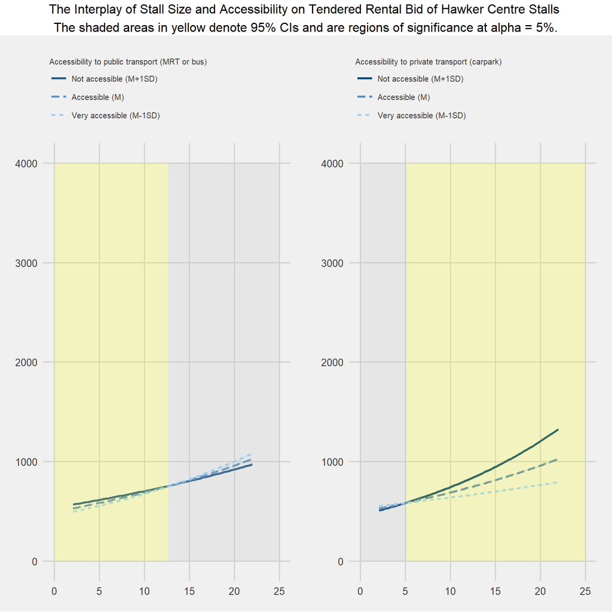

```r
gridExtra::grid.arrange(poisson_interact_public_trnspt_A,
                        poisson_interact_private_trnspt_A,
                        ncol=2,
                        top="The Interplay of Stall Size and Accessibility on Tendered Rental Bid of Hawker Centre Stalls \nThe shaded areas in yellow denote 95% CIs and are regions of significance at alpha = 5%."
                        )
```

## 1.6.3 Stall Type X Location

We will then commence our next investigation on stall type as the explanatory variable and location as interaction term. We will start off by creating the model.

```r
poisson_interact_B <- glm(tendered_bid ~
                            cooked * central + stall_area_sqm +
                            min_dist_public_trnspt + min_dist_private_trnspt,
                           family="poisson",
                           data = successful_bids_df)

broom::glance(poisson_interact_B);broom::tidy(poisson_interact_B) %>% as_tibble()
```

```
## # A tibble: 1 x 8
##   null.deviance df.null    logLik      AIC      BIC deviance df.residual  nobs
##           <dbl>   <int>     <dbl>    <dbl>    <dbl>    <dbl>       <int> <int>
## 1      5315300.    5675 -1484958. 2969930. 2969976. 2926330.        5669  5676
```

```
## # A tibble: 7 x 5
##   term                    estimate  std.error statistic  p.value
##   <chr>                      <dbl>      <dbl>     <dbl>    <dbl>
## 1 (Intercept)             5.51     0.00219       2516.  0
## 2 cooked                  1.30     0.00117       1113.  0
## 3 central                 0.484    0.00474        102.  0
## 4 stall_area_sqm          0.0351   0.000277       127.  0
## 5 min_dist_public_trnspt  0.000215 0.00000220      97.9 0
## 6 min_dist_private_trnspt 0.000137 0.00000188      72.8 0
## 7 cooked:central          0.103    0.00495         20.9 4.35e-97
```

To find out how much the location affects the relationship between stall type and tendered rental bid, we created a grid to store the predicted values based on the model `poisson_interact_B`. The numerical variables are controlled by setting them to the mean.

```r
stall_size_X_location_grid <- successful_bids_df %>%
  modelr::data_grid(cooked,
                    central,
                    stall_area_sqm = mean(stall_area_sqm),
                    min_dist_public_trnspt = mean(min_dist_public_trnspt),
                    min_dist_private_trnspt = mean(min_dist_private_trnspt),
  ) %>%
  mutate(predicted_tendered_bid = predict(poisson_interact_B, . , type = "response"))
```

We then visualize the model.

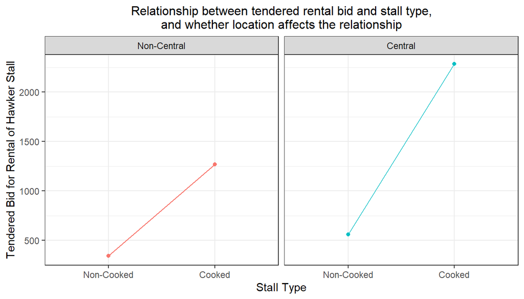

```r
stall_size_X_location_grid %>%
  ggplot(aes(x = factor(cooked), # Explanatory variable
             y = predicted_tendered_bid, # Y-hat
             group = factor(central) # Moderator
  )
  ) +
  scale_x_discrete(labels=c("Non-Cooked", "Cooked")) +
  scale_color_discrete(name="Hawker Centre Location",
                       limits = c("0", "1"),
                       labels = c("Non-Central", "Central")
  ) +
  geom_point(aes(color=factor(central))) +
  geom_line(aes(color=factor(central))) +
  labs(title = "Relationship between tendered rental bid and stall type,\nand whether location affects the relationship",
       x="Stall Type",
       y="Tendered Bid for Rental of Hawker Stall"
  ) +
  theme_bw() +
  facet_wrap(. ~ factor(central),
             labeller=as_labeller(c("0"="Non-Central","1"="Central"))) +
  theme(plot.title = element_text(size=12,
                                  hjust=0.5),
        plot.subtitle = element_text(size=11),
        legend.position = "none"
        )
```

As the interaction terms are significant, we will proceed to probe interactions, with location as the interaction term.

```r
interactions::sim_slopes(poisson_interact_B,
                         pred = cooked,
                         modx = central,
                         johnson_neyman = F)
```

```
## SIMPLE SLOPES ANALYSIS
##
## Slope of cooked when central = 0.00 (0):
##
##   Est.   S.E.    z val.      p
## ------ ------ --------- ------
##   1.30   0.00   1113.23   0.00
##
## Slope of cooked when central = 1.00 (1):
##
##   Est.   S.E.   z val.      p
## ------ ------ -------- ------
##   1.41   0.00   291.02   0.00
```

The results of the simple slopes analysis show that p = 0 for scenario where the hawker stalls are in the central and non-central regions of Singapore. Given that p-value is less than 0.05, we can deduce that interaction effects are significant where the location of the hawker stall is in the central and non-central regions.

```r
interactions::sim_slopes(poisson_interact_B,
                         pred = central,
                         modx = cooked,
                         johnson_neyman = T)
```

```
## JOHNSON-NEYMAN INTERVAL
##
## When cooked is OUTSIDE the interval [-5.25, -4.20], the slope of central is
## p < .05.
##
## Note: The range of observed values of cooked is [0.00, 1.00]
##
## SIMPLE SLOPES ANALYSIS
##
## Slope of central when cooked = 0.00 (0):
##
##   Est.   S.E.   z val.      p
## ------ ------ -------- ------
##   0.48   0.00   102.08   0.00
##
## Slope of central when cooked = 1.00 (1):
##
##   Est.   S.E.   z val.      p
## ------ ------ -------- ------
##   0.59   0.00   392.86   0.00
```

The Johnson-Neyman interval shows that the slope for location (central) is significant when stall type (cooked) is outside the interval [-5.25, -4.20]. The p-value are 0 in both the scenarios where stall is selling cooked and non-cooked food.

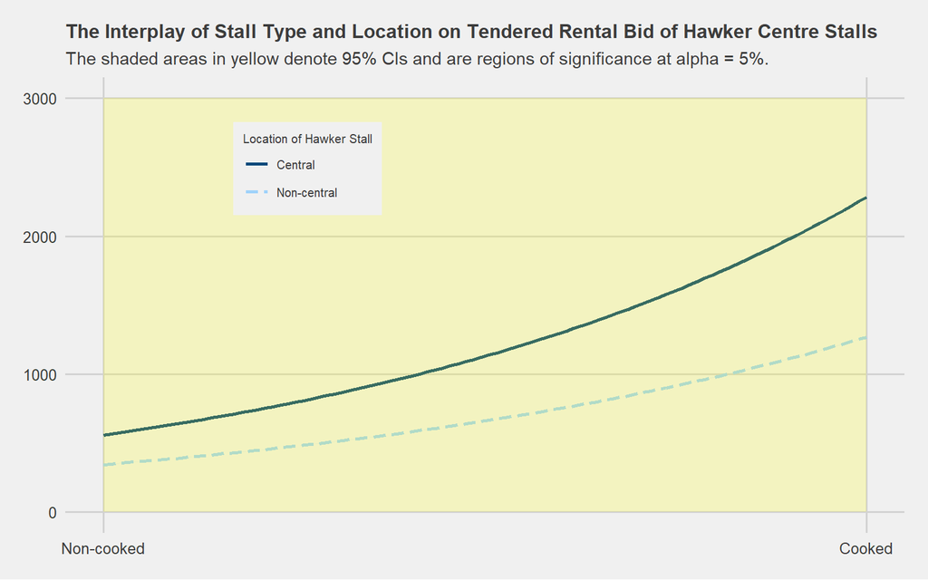

```r
interactions:: interact_plot(poisson_interact_B,
                             pred = "cooked",
                             modx = "central",
                             modx.labels = c("Non-central",
                                             "Central"),
                             x.label = "Stall Type",
                             y.label ="Tendered Bid for Rental of Hawker Stall",
                             interval = T,
                             int.width = 0.95,
                             vary.lty = T,
                             line.thickness = 1,
                             legend.main = "Location of Hawker Stall"
) +
  scale_x_continuous(breaks = c(0,1),
                     labels = c("Non-cooked","Cooked")) +
  ggthemes::theme_fivethirtyeight() +
  labs(title="The Interplay of Stall Type and Location on Tendered Rental Bid of Hawker Centre Stalls",
      subtitle="The shaded areas in yellow denote 95% CIs and are regions of significance at alpha = 5%.") +
  annotate("rect",
           fill = "yellow",
           alpha = 0.2,
           xmin = 0,
           xmax = 1,
           ymin = 0,
           ymax = 3000) +
  theme(plot.title = element_text(size=12),
        plot.subtitle = element_text(size=11),
        legend.position = c(0.2,0.8),
        legend.direction = "vertical",
        legend.justification = "left",
        legend.title=element_text(size=7.5),
        legend.text=element_text(size=7.5)
  )
```

## 1.7 Interpretation of the Results

From our data science project, we have deduce the following:

1. The relationships between the stall size and the tendered rental bid depends on the accessibility of the hawker stall. Specifically, hawker stalls which are very accessible by `public transport` seems to garner a higher tendered bid for larger stall sizes. On the contrary, hawker stalls which are very accessible by `private transport` seems to garner a lower tendered rental bid for larger stall size. As the results are correlational, further investigation with a/b testing should follow to ascertain a causal relationship.
2. The relationships between stall type and tendered bid per month also depends on the location. It appears that cooked food stalls which are centrally located has higher tendered bid as compared to cooked food stalls which are not centrally located. Similarly, non-cooked food stalls which are centrally located has a higher tendered bid as compared to stalls that are not centrally located. Again, as the results are correlational, further investigation with a/b testing should follow to ascertain a causal relationship.

## 1.8 Implications

**Relationship between tendered rental bids and stall size, whether the accessibility to public/private transport alters the relationship**

Based on the model visualization, for stalls that are greater than 13 square metres, the tendered rental bid shows an upward trend as stall size increases. This observation could be attributed to the fact that bidders are more likely to place a much higher bid price for a stall that is accessible by people due to the convenience of buses and MRTs located nearby. With a larger crowd, there would be a higher tendency for people to patronize the stalls and enticing people to buy the food sold in the stalls. With that, the stall owner would gain more profit as there is greater demand for the food. For those stalls that are not accessible by public transport, the tendered bids were lower. This could be due to the fact that these bidders do not foresee a large crowd patronizing the stalls due to its inaccessibility, hence it may not be prudent to bid a high price for the stalls.

However, for stalls that are smaller than 13 square metres, the tendered bids for rental seem to suggest bidders are more likely to bid higher amount for stalls that are inaccessible by public transport. A further analysis is required to investigate if there are other factors causing this observation.

On the contrary, for stalls that are accessible by private transport, the variance between stalls that are very accessible compared to stalls that are inaccessible differs greatly. The highest tendered bid for rental for accessible places by private transport accounts for merely $800, compared to the highest tendered bid for rental for inaccessible places of approximately $1,300. This could be due to the fact that some stalls categorised under “very accessible to private transport” could be inaccessible to public transports. Hence, the bidders are likely to bid a lower price as they could be under the impression that other bidders are unlikely to compete with them for these stalls. Similarly, those stalls categorised under “not accessible to private transport” could be accessible to public transport which resulted in a much higher tendered bids. Further investigation is necessary to support our conjecture.

**Relationship between tendered rental bids and stall type, whether the location of stall affects the relationship**

The graph illustrates a much higher tendered bid for rental of stalls that are selling cooked food in the central region. For non-cooked food stalls located in the non-central region, they garnered the lowest tendered bid for rental of hawker stalls. For non-cooked stalls, the tendered bids for rental are relatively lower for both central and non-central regions. Such observations may be due to the assumption made by the bidders that there will be little competition from other bidders who are planning to sell non-cooked food to the consumers, hence it may not be wise for them to bid a high price to secure the stalls.

For cooked-stalls, the tendered bids for rental in the central region is much higher than those in non-central regions. Due to a wide variety of cuisines sold in Singapore, there is stiff competition between hawkers to sell food that are appealing to the public. Therefore, in terms of cooked food, there is higher demand from the public which may possibly result in bidders placing a higher bid in order to secure the stalls.

## 1.9 Limitations and Future Directions

Though these data are obtained from NEA’s website, it is worthy to note there are several terms and conditions for NEA to consider before selecting the tenderer for a particular stall. One of these terms and conditions states that “The NEA does not bind itself to accept the highest or any offer at all and the decision of the NEA shall be final.” Based on the above statement, perhaps the tendered bids for rental of hawker stalls does not reflect the true bid amount that won the tender for hawker stalls. There may be a lack of transparency on how these tendered bids are selected, hence affecting the accuracy of the data published on NEA’s website.

In addition, the tendered bids for rental of hawker stalls do not reflect the true costs of operating a hawker stall. These hidden costs include the service and conservancy charge, refuse removal fee, license fees, Goods and Services Tax (GST) and monthly charges such as water and electricity bills which could vary depending on the type of food sold for a hawker stall. While it may seem that the costs to operate a hawker centre is low based on the data, but one must note that there are other costs which could possibly increase the total costs of running a hawker stall.

Due to the above reasons, the analysis above based on the data obtained from NEA serves as a reference for future bidders who have plans to venture into opening a hawker stall. More data could be obtained from NEA to provide a holistic and accurate data analysis for the tendered bids for rental of hawker stalls.

It is also important to note that current analysis only look into the (1) Stall Size, (2) Distance to Public Transport and (3) Distance to Private Transport as the key variables that could affect the Tendered Rental Bid. Thus, it is recommended that the following variables be included in future analysis:

- Vicinity to Residential, Maturity of Estate, Commercial (CBD, Non-CBD), Industrial Areas (Labour Intensive)
- Ethnic Demography (eg. Chinatown, Little India, Geylang Serai, Holland Village, etc)

Another point to note is that the hawker centres dataset only reflects tendered rental bid for government-managed hawker stalls. Dataset could be expanded in future to include privately owned hawker stalls.